# EDA - Presidential Election Data 2020

### Importing Libraries

```r
library(tidyverse)
library(dplyr)
library(ggplot2)
library(usmap)
library(maps)
library(stringr)
```

### Importing the data

1. dataset ‘data1’: This dataset gives the state-wise total registered voters
2. dataset ‘data2’: This dataset gives percentage of voting happened for year 2020 in each county
3. dataset ‘data3’: This dataset gives the total votes received by a presidential candidate in each counties, party of the presidential candidate and a variable showing if he won or lost that county

```r
data1 <- read.csv('president_state.csv')  #this dataset gives the state-wise total registered voters
str(data1)
```

```
## 'data.frame':    52 obs. of  2 variables:
##  $ state      : chr  "Delaware" "District of Columbia" "Florida" "Georgia" ...
##  $ total_votes: int  504010 333682 11067456 4993055 574341 868125 5939321 3034993 1688310 1334330 ...
```

```r
data2 <- read.csv('president_county.csv')  #this dataset gives percentage of voting happened for year 2020 in each county
str(data2)
```

```
## 'data.frame':    4633 obs. of  5 variables:
##  $ state        : chr  "Delaware" "Delaware" "Delaware" "District of Columbia" ...
##  $ county       : chr  "Kent County" "New Castle County" "Sussex County" "District of Columbia" ...
##  $ current_votes: int  87025 287633 129352 40631 31929 43188 44361 45176 58315 37836 ...
##  $ total_votes  : int  87025 287633 129352 45392 37140 47692 45917 44719 57889 37287 ...
##  $ percent      : int  100 100 100 90 86 91 95 95 95 95 ...
```

```r
data3 <- read.csv('president_county_candidate.csv')  #This dataset gives the total votes received by a presidential candidate in each counties, party and a variable showing if he won or lost
str(data3)
```

```
## 'data.frame':    31213 obs. of  6 variables:
##  $ state      : chr  "Delaware" "Delaware" "Delaware" "Delaware" ...
##  $ county     : chr  "Kent County" "Kent County" "Kent County" "Kent County" ...
##  $ candidate  : chr  "Joe Biden" "Donald Trump" "Jo Jorgensen" "Howie Hawkins" ...
##  $ party      : chr  "DEM" "REP" "LIB" "GRN" ...
##  $ total_votes: int  44552 41009 1044 420 195034 88364 2953 1282 71230 56682 ...
##  $ won        : logi  TRUE FALSE FALSE FALSE TRUE FALSE ...
```

### Exploratory Data Analysis for ‘data1’

```r
# Adding the state-wise population in 2020 to the data1

popl <- read.csv("popl.csv")    # importing data
colnames(popl)[colnames(popl) == 'ï..state' ] <- 'state' # Changing the colname

# Joining the popl dataset with data1 by 'state' variable
state_df <- popl %>% left_join(data1, by = 'state') %>%
  na.omit() %>%
  mutate(registered_voter_percent = round((total_votes/popl)*100))  # Finding the percent of registered voters with respect to the total population

str(state_df)
```

```
## 'data.frame':    51 obs. of  4 variables:
##  $ state                   : chr  "California" "Texas" "Florida" "New York" ...
##  $ popl                    : int  39937500 29472300 21993000 19440500 12820900 12659700 11747700 10736100 10611900 10045000 ...
##  $ total_votes             : int  17174536 11279106 11067456 6795886 6893186 5939321 5764587 4993055 5524813 5534874 ...
##  $ registered_voter_percent: num  43 38 50 35 54 47 49 47 52 55 ...
##  - attr(*, "na.action")= 'omit' Named int 34
##   ..- attr(*, "names")= chr "34"
```

#### Visualization for state-wise population

Let’s see how the population is distributed state-wise and find the state with highest population.

Through the the visualization we can say that California, Texas, Florida and New York are the states with highest population

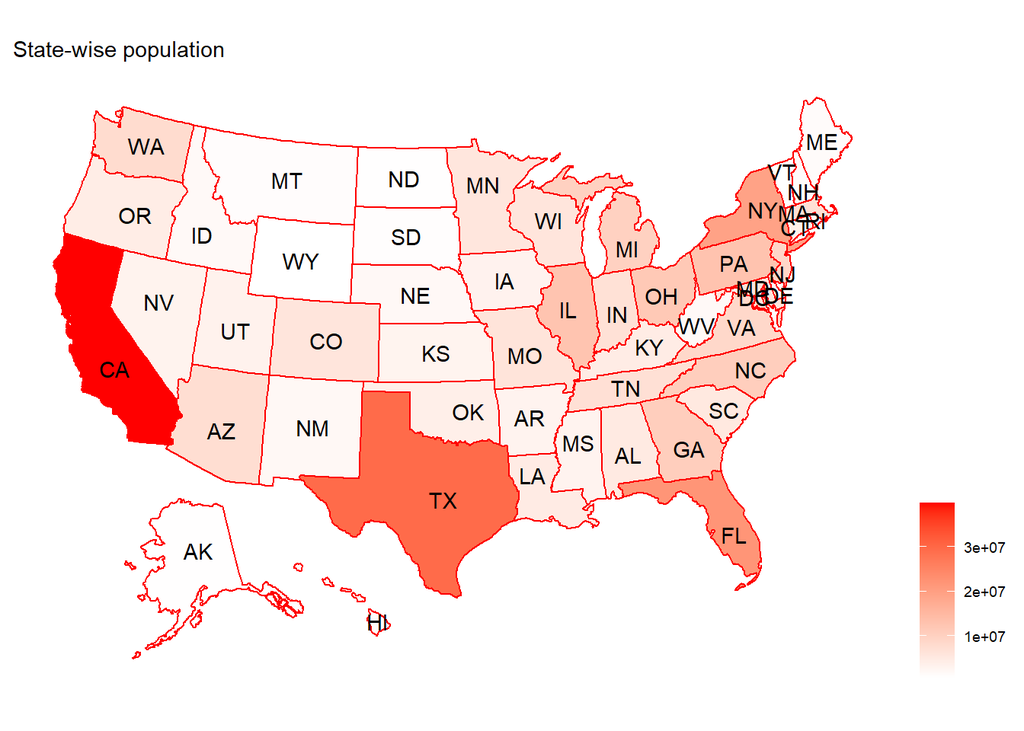

```r
# Statewise population visualization

usmap::plot_usmap(data = state_df, values = "popl", color = "red", labels = TRUE) +
  scale_fill_continuous(low = "white", high = "red", name = "") +
  theme(legend.position = "right") + labs(title = "State-wise population")
```

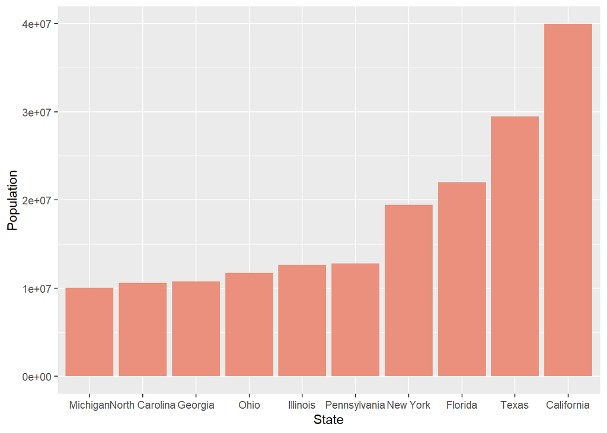

```r
state_df %>% arrange(desc(popl)) %>%
  slice(., n = 1:10, popl) %>%
  ggplot(., aes(x= reorder(state, popl), y=popl)) +
              geom_bar(stat='identity', fill = "#EA907C") + labs(x = "State", y = "Population") +
              theme_grey()
```

#### Visualization for registered voters percentage

Which are the states with highest percentage of registered voters?

Vermont, New Hampshire, Maine, Minnesota, Wisconsin, Montana, and Colorado are the states with highest percentage of registered voters

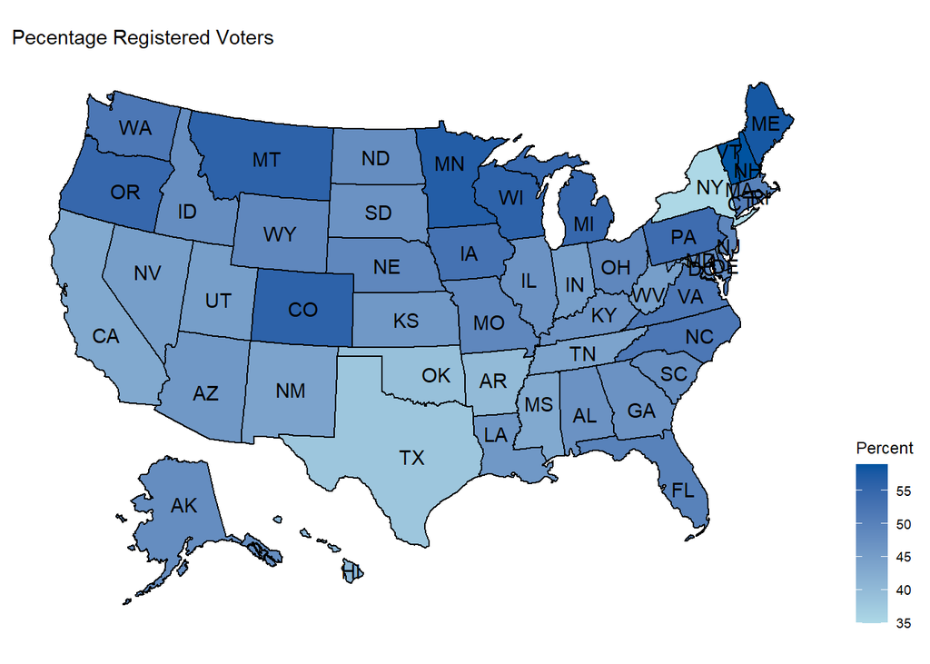

```r
# Percentage of registered users
usmap::plot_usmap(data = state_df, values = "registered_voter_percent", labels = TRUE) +
  scale_fill_continuous(low = "light blue", high = "#0053a0", name = "Percent") +
  theme(legend.position = "right") +labs(title = "Pecentage Registered Voters")
```

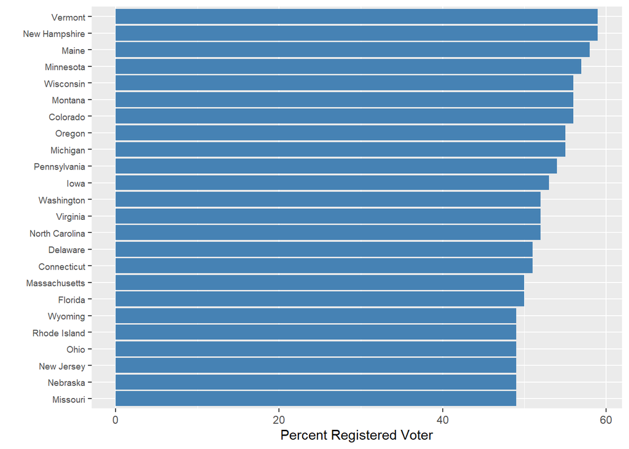

```r
state_df %>% arrange(desc(registered_voter_percent)) %>%
  top_n(., 20, registered_voter_percent) %>%
  ggplot(., aes(x= reorder(state, registered_voter_percent), y=registered_voter_percent)) +
              geom_bar(stat='identity', fill = "steelblue") +
              theme(axis.text.y = element_text(size = 7)) + coord_flip() + xlab("") + ylab("Percent Registered Voter")
```

### Exploratory Data Analysis for ‘data2’

2020 voter turnout is the highest in over a century. Lets look at the the voter turnout by county

#### Looking at the percentage of voter turn out by County

Plotting the counties using FIPS

```r
# Voter turnout by county

county_data <- data2 %>% dplyr::select(county, percent, state)   # pulling the required columns
colnames(county_data) <- c("subregion", "percent", "region")     # changing colname for joining tables

# Manipulating the character arrays in the county_data to match with the other table
county_data$subregion <- str_to_lower(county_data$subregion)
county_data$region <- str_to_lower(county_data$region)
county_data$subregion <- str_replace(county_data$subregion, " county", "")

# County map - getting the co-ordinates of the county
county_coord <- map_data("county")

# Joining county map to county_data
county_map <- county_coord %>% left_join(county_data, by = c("subregion", "region"))

sum(is.na(county_map))  # There are 5543 na values i.e the voters turnout for these county is not availabe
```

```
## [1] 5543
```

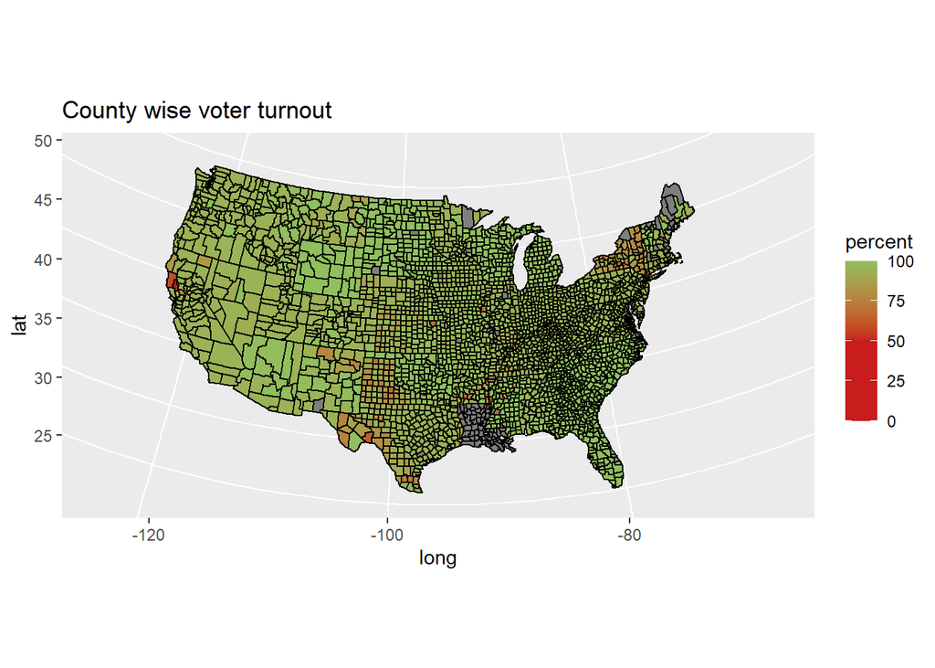

```r
# Plot
ggplot(county_map, aes(long, lat, group = group)) +
  geom_polygon(aes(fill = percent), color = "black") +
  scale_fill_gradient2(low="#c91c1c", high="#90bf5e", mid = "#c91c1c", midpoint = 50) +
  coord_map(projection = "albers", lat0 = 39, lat1 = 45) +
  labs(title = "County wise voter turnout") +
  theme(legend.position = "right")
```

```r
# the grey part the regions whose voting data is not yet available
```

### Exploratory Data Analysis - data3

What are the total number of votes received by Joe Biden and Donald Trump?

- Joe Biden - 79,841,918
- Donald Trump - 73,746,254

```r
str(data3)
```

```
## 'data.frame':    31213 obs. of  6 variables:
##  $ state      : chr  "Delaware" "Delaware" "Delaware" "Delaware" ...
##  $ county     : chr  "Kent County" "Kent County" "Kent County" "Kent County" ...
##  $ candidate  : chr  "Joe Biden" "Donald Trump" "Jo Jorgensen" "Howie Hawkins" ...
##  $ party      : chr  "DEM" "REP" "LIB" "GRN" ...
##  $ total_votes: int  44552 41009 1044 420 195034 88364 2953 1282 71230 56682 ...
##  $ won        : logi  TRUE FALSE FALSE FALSE TRUE FALSE ...
```

```r
# Total votes received by top two candidates
candidate_vote <- data3 %>% dplyr::select(candidate, total_votes) %>%
  filter(candidate == "Joe Biden" | candidate == "Donald Trump") %>%
  group_by(candidate) %>%
  summarise(total_votes_by_candidate = sum(total_votes)) %>%
  arrange(desc(total_votes_by_candidate))
candidate_vote
```

```
## # A tibble: 2 x 2
##   candidate    total_votes_by_candidate
##   <chr>                           <int>
## 1 Joe Biden                    79841918
## 2 Donald Trump                 73746254
```

Votes received by presidential candidates statewise:

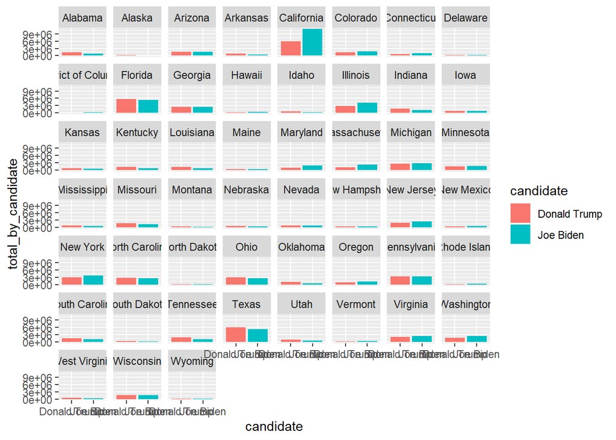

```r
# Votes received by Joe Biden and Donald Trump in each state
candidate_vote1 <- data3 %>%
  dplyr::select(candidate, total_votes,state) %>%
  filter(candidate == "Joe Biden" | candidate == "Donald Trump") %>%
  group_by(candidate, state) %>%
  na.omit() %>%
  summarise(total_by_candidate = sum(total_votes))

# Plotting
ggplot(data = candidate_vote1, aes(candidate, total_by_candidate, fill = candidate)) +
  geom_col() +
  facet_wrap(~ state)
```

Percent votes received by candidates:

Candidates other then Joe Biden and Donald Trump are under “Others” category

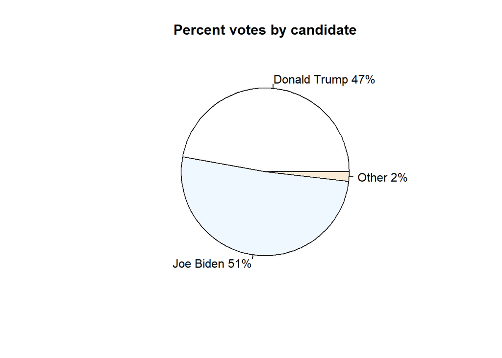

```r
votes_rec <- data3 %>%
  dplyr::select(state, candidate, party, total_votes) %>%
  mutate(., Updated_candidate = ifelse(candidate == "Joe Biden" | candidate == "Donald Trump", candidate, "Other")) %>% group_by(Updated_candidate) %>% arrange(desc(total_votes))

votes_rec$candidate = NULL

total_votes <- votes_rec %>% summarise(candidate_total = sum(total_votes))

slices <- c(total_votes$candidate_total)
lbls <- c(total_votes$Updated_candidate)
pct <- round(slices/sum(slices)*100)
lbls <- paste(lbls, pct)
lbls <- paste(lbls,"%",sep="")
pie(slices, lbls, main = "Percent votes by candidate", col=colors(length(lbls)))
```

Percent Votes received by **Joe Biden** in all state

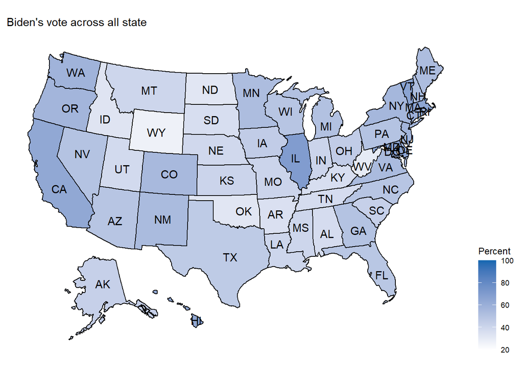

```r
vote_joe <- data3 %>% dplyr::select(state, candidate, total_votes) %>%
  filter(candidate == "Joe Biden")  %>%
  group_by(state) %>%
  summarise(total_joe = sum(total_votes)) %>%
  left_join(data1, by = "state") %>%
  mutate(joe_percent = round((total_joe/total_votes)*100))

usmap::plot_usmap(data = vote_joe, values = "joe_percent", labels = TRUE) +
  scale_fill_continuous(low = "white", high = "#1167b1", limits = c(20, 100), name = "Percent") +
  theme(legend.position = "right") + labs(title = "Biden's vote across all state")
```

Percent Votes received by **Donald Trump** in all state

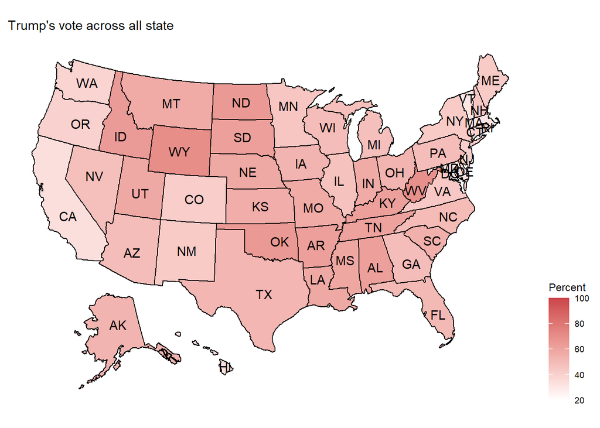

```r
vote_trump <- data3 %>% dplyr::select(state, candidate, total_votes) %>%
  filter(candidate == "Donald Trump")  %>%
  group_by(state) %>%
  summarise(total_donald = sum(total_votes)) %>%
  left_join(data1, by = "state") %>%
  mutate(donald_percent = round((total_donald/total_votes)*100))

usmap::plot_usmap(data = vote_trump, values = "donald_percent", labels = TRUE) +
  scale_fill_continuous(low = "white", high = "#CB454A", limits = c(20, 100), name = "Percent") +
  theme(legend.position = "right") + labs(title = "Trump's vote across all state")
```

Win by county

```r
# Filtering to find the candidate that won in each county
county_win <- data3 %>% dplyr::select(state, county, candidate, won) %>%
  filter(won == TRUE) %>%
  arrange(state, county)

# Changing colnames to match fips data
colnames(county_win) <- c("region","subregion", "candidate", "won")

# String Manipulation
county_win$region <- str_to_lower(county_win$region)
county_win$subregion <- str_to_lower(county_win$subregion)
county_win$subregion <- str_replace(county_win$subregion, " county", "")

# Joining the table
county_map2 <- county_coord %>% left_join(county_win, by = c("subregion", "region"))

head(county_map2)
```

```
##        long      lat group order  region subregion    candidate  won
## 1 -86.50517 32.34920     1     1 alabama   autauga Donald Trump TRUE
## 2 -86.53382 32.35493     1     2 alabama   autauga Donald Trump TRUE
## 3 -86.54527 32.36639     1     3 alabama   autauga Donald Trump TRUE
## 4 -86.55673 32.37785     1     4 alabama   autauga Donald Trump TRUE
## 5 -86.57966 32.38357     1     5 alabama   autauga Donald Trump TRUE
## 6 -86.59111 32.37785     1     6 alabama   autauga Donald Trump TRUE
```

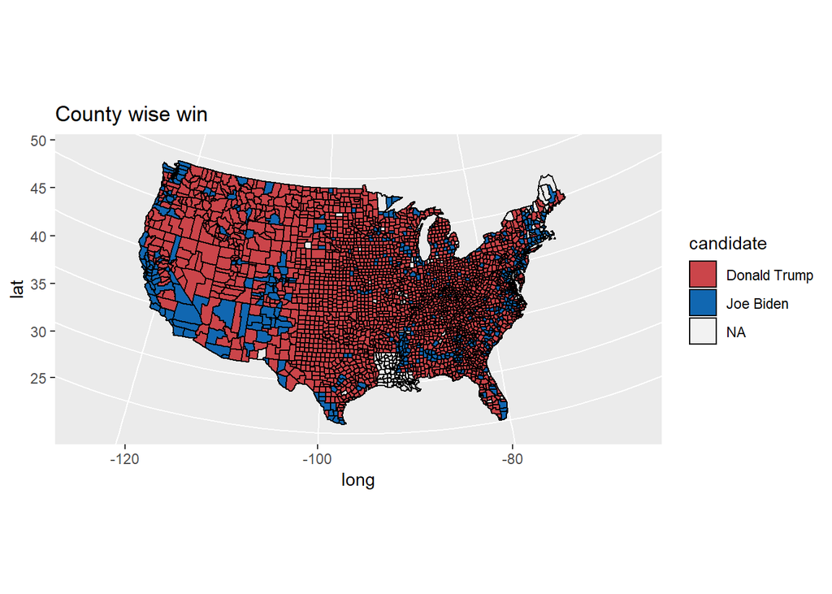

```r
# Visualization

ggplot(county_map2, aes(long, lat, group = group)) +
  geom_polygon(aes(fill = candidate), color = "black") +
  scale_fill_manual(values = c("#CB454A", "#1167b1")) +
  coord_map(projection = "albers", lat0 = 39, lat1 = 45) +
  labs(title = "County wise win")
```

```r
# the grey part the regions whose voting data is not yet available
```